# MSCA 37006 R Workshop

© Danny Ng

August 24, 2018

# 1 Workshop Information

Title: MSCA 37006 R Workshop  
Date and time: August 24, 2018 3PM - 9PM and August 25, 2018 9AM - 3PM  
Location: University of Chicago Gleacher Center  
Instructor: Danny Ng lianhuanng@uchicago.edu

# 2 References

Official websites

- R https://www.r-project.org/
- RStudio https://www.rstudio.com/
- Microsoft R Open https://mran.microsoft.com/open/
- R Markdown http://rmarkdown.rstudio.com/

Tutorials

- The R Manuals https://cran.r-project.org/manuals.html
- Reference Card https://cran.r-project.org/doc/contrib/Short-refcard.pdf
- RStudio Cheat Sheets https://www.rstudio.com/resources/cheatsheets/
- Quick-R https://www.statmethods.net/
- Cookbook for R http://www.cookbook-r.com/
- Google’s R Style Guide https://google.github.io/styleguide/Rguide.xml
- Advanced R by Hadley Wickham http://adv-r.had.co.nz/
- R for Data Science http://r4ds.had.co.nz/

Packages

- R Documentation https://www.rdocumentation.org/
- Crantastic https://crantastic.org/

Blogs

- R-bloggers https://www.r-bloggers.com/

Books

- R for Everyone by Jared Lander https://www.jaredlander.com/r-for-everyone/
- R in Action by Robert I. Kabacoff https://www.manning.com/books/r-in-action-second-edition
- R Cookbook by Paul Teetor http://shop.oreilly.com/product/9780596809164.do
- R Graphics Cookbook by Winston Chang http://shop.oreilly.com/product/0636920023135.do
- The Art of R Programming by Norman Matloff https://www.nostarch.com/artofr.htm
- The R Inferno http://www.burns-stat.com/documents/books/the-r-inferno/
- Modern Applied Statistics with S by W. N. Venables and B. D. Ripley https://www.stats.ox.ac.uk/pub/MASS4/

# 3 R and RStudio

R is a free software environment for statistical computing and graphics. It is a programming language with many built-in statistical tools and cutting edge third-party packages.

RStudio is an integrated development environment (IDE) for R. It includes a console, syntax-highlighting editor that supports direct code execution, as well as tools for plotting, history, debugging and workspace management.

## 3.1 Installation

To install R:

1. Go to the official R website https://www.r-project.org/
2. Click [CRAN](https://cran.r-project.org/mirrors.html) on the left page and select any mirror URL
3. For Windows, click [Download R for Windows](https://cloud.r-project.org/bin/windows/) → [base](https://cloud.r-project.org/bin/windows/base/) → [Download R 3.5.1 for Windows](https://cloud.r-project.org/bin/windows/base/R-3.5.1-win.exe)
4. For Mac OS X 10.11 El Capitan and higher, click [Download R for (Mac) OS X](https://cloud.r-project.org/bin/macosx/) → R-3.5.1.pkg
5. Install the downloaded installation file

To install RStudio:

1. Go to the official RStudio website https://www.rstudio.com/
2. Click [Download RStudio](https://www.rstudio.com/products/RStudio/) → Desktop → [Download RStudio Desktop](https://www.rstudio.com/products/rstudio/download/#download) and select the Installer for your operation system
3. Install the downloaded installation file

## 3.2 Overview of User Interface

- Base R console vs RStudio
- RStudio GUI
  - Console
  - Environment: Import Dataset
  - Plots: Export
  - Files: More → Set As Working Directory
  - Packages: Install
  - Help
  - File → New File → R Script and .R files
- Code execution: Ctrl+Enter (on Windows) or Cmd+Enter (on Mac), Run button
- Comment with `#`
- To have a clean workspace at RStudio startup, go to Tools → Global Options… → General → uncheck the following:
  - Restore most recently opened project at startup
  - Restore previously open source documents at startup
  - Restore .RData into workspace at startup
  - Save workspace to .RData on exit: Never

## 3.3 Installing Package

- To install a package from the Comprehensive R Archive Network (CRAN), go to Packages → Install → type in the package name.
- You can also install a package by executing the `install.packages()` function in the console.

```r
install.packages("ggplot2")
install.packages("dplyr")
install.packages("rmarkdown")
```

- After installing a package, you need to load it into the current workspace using the `library()` function before you can use the package in the current session.

```r
library(ggplot2)
library(dplyr)
```

## 3.4 Help

Here are some ways to self-help:

1. Try the code with some sample data and see how it behaves. The R console is interactive.
2. Use `?` to look up the R documentation for an exact function function e.g. `?mean`. But R documentation can be hard to read.
3. Use `??` to search for a keyword in the R documentation e.g. `?histogram`.
4. Google, Stack Overflow, … e.g. `R heatmap`

# 4 Using the R Console as a Calculator

```r
# Number arithmetic.
1 + 0.2 * (3e2 - 4) / 5e-1 # Integer, decimal, and exponential number.
sqrt(3 ** 2 + 4 ^ 2) # Both ** and ^ are exponent.

# Boolean expression.
1 < 2 # TRUE or FALSE value.
(5 >= 4) && (1 != 2)
```

```
[1] 119.4
[1] 5
[1] TRUE
[1] TRUE
```

## 4.1 Basic Atomic Data Types

- Logical: `TRUE`, `FALSE`, `T`, `F`
- Number: `1`, `2.3`, `-4`, `5e6` is $5\times 10^6$, `-7.8e-9`
- Character: `'Hello'`, `"World"`
- Special value: `pi`, `Inf`, `-Inf`, `NaN` is not a number NaN
- Missing value: `NA` not available
- Nothing: `NULL`

## 4.2 Arithmetic

- `+`, `-`, `*`, `/`, `**`, `^`, `(`, `)`, `%%` for modulus
- Built-in mathematical functions: `abs()`, `sqrt()`, `exp()`, `log()`, `log10()`, `cos()`, `sin()`, `tan()`, `round()`, `ceiling()`, `floor()`, `sign()`

## 4.3 Boolean Logic

- Comparison: `==`, `>`, `<`, `!=`, `<=`, `>=`
- Boolean operators: `!` NOT, `&&` AND, `||` OR
- Built-in functions: `is.finite()`, `is.infinite()`, `is.nan()`, `is.na()`, `is.null()`

## 4.4 Variable and Naming

- Storing value into variable: `=`, `<-`

```r
price = 2     # Bad style
quantity <- 3 # Good style
total <- price * quantity
is.expensive <- total >= 4
is.expensive # Show the value of a variable
```

```
[1] TRUE
```

```r
# Text.
question <- 'What are you doing?'
response <- "I'm learning R." # Both ' and " are OK.
```

- Naming convention: `is.expensive`, `is_expensive`, `IsExpensive`
  - All are OK.
  - The dot style is the convention.
  - Case sensitive
- Reserved keywords `?Reserved` and built-in functions, for example:
  - `c` for combining
  - `q` for quitting R
  - `t` for matrix transpose
  - `data` for loading data sets
  - `df` for density of the F distribution
  - `time` and `date` for time series
- A useful way to check if a word is R’s built-in keyword or function: `?c`
- [Weakly typed](https://en.wikipedia.org/wiki/Strong_and_weak_typing): The data type of the variable is not pre-defined but is inferred from the data at runtime.
- Variable name is reusable.

```r
x <- 1
x <- "one" # The old value is gone.
x
```

```
[1] "one"
```

## 4.5 Implicit Type Conversion / Coercion

- When a binary operation is involved for data of two different types, the lower type is first converted to a higher type implicitly. See https://en.wikipedia.org/wiki/Type_conversion.
- R’s data type hierarchy: logical, integer, double, character

```r
TRUE + 2 # TRUE is converted to 1 and FALSE is converted to 0.
FALSE == 0
1 == "1"
```

```
[1] 3
[1] TRUE
[1] TRUE
```

# 5 Basic Data Structure

## 5.1 Vector

- A vector is a sequence of data of the same type.
- How to create a vector? Use `c()`, `numeric()`, `:`, `seq`, or `rep`.

```r
numbers <- c(1, -2, 3) # Here "c" is a built-in function to combine items.
phones <- c("Apple", "Samsung", "Nokia", "HTC")
numbers <- numeric(5) # Vector of 0's.

x <- rep(1, 5)
y <- 2:7 # Increment by 1.  Note that 7:2 is descending.
z <- seq(0, 100, length.out=6)) # Evenly-spaced
numbers <- c(x, y) # Concatenate two (or more) vectors together.
```

- Indexing: How to select specific elements from a vector?

```r
x <- c(1, 3, 5, 7, 9)
x[2]       # By a single integer
x[2:4]     # By a sequence of integers
x[c(4,2)]  # By a set of integers in a particular ordering
x[-3]      # Omit the 3rd element
x[-c(3,4)] # Omit the specified indices

idx <- c(FALSE, FALSE, TRUE, FALSE, TRUE)
x[idx]     # By logical indexing
```

```
[1] 3
[1] 3 5 7
[1] 7 3
[1] 1 3 7 9
[1] 1 3 9
[1] 5 9
```

- Assigning values to specific elements of a vector

```r
x <- 1:10
x[1] <- 10
x
x[c(3, 2)] <- c(20, 30) # Note the ordering of the indexing
x
x[4:5] <- 40 # Assign the same value to both elements
x
x[7:10] <- c(70, 80) # Recycling the provided values
x
```

```
 [1] 10  2  3  4  5  6  7  8  9 10
 [1] 10 30 20  4  5  6  7  8  9 10
 [1] 10 30 20 40 40  6  7  8  9 10
 [1] 10 30 20 40 40  6 70 80 70 80
```

- Vectorization: All binary operators, arithmetic, and math functions are vectorize-able i.e. element-wise operations.

```r
x <- 1:5
y <- 6:10
-x
sqrt(x)
x ^ 2
x * y
```

```
[1] -1 -2 -3 -4 -5
[1] 1.000000 1.414214 1.732051 2.000000 2.236068
[1]  1  4  9 16 25
[1]  6 14 24 36 50
```

- Vectorized AND and OR: `&`, `|`

```r
x <- c(TRUE, TRUE, FALSE)
y <- c(TRUE, FALSE, FALSE)
x & y
x | y
```

```
[1]  TRUE FALSE FALSE
[1]  TRUE  TRUE FALSE
```

```r
x <- 1:10
x[x > 4 & x <= 8] # Vectorized > and <= and & with boolean indexing.
```

```
[1] 5 6 7 8
```

- Built-in functions for vector:
  - `length()`, `head()`, `tail()`, `rev()`
  - `unique()`, `is.element()` or `%in%`
- Built-in functions for logical vector:
  - `all()`, `any()`, `which()`
- Built-in functions for numeric vector:
  - `sum()`, `prod()`, `max()`, `min()`, `range()`, `which.min()`, `which.max()`, `cumsum()`, `cumprod()`, `diff()`
  - `mean()`, `median()`, `var()`, `sd()`
  - `sort()`, `order()`, `rank()`
  - `pmin()`, `pmax()`

```r
x <- c(1,3,7,2,9,6)
length(x)
head(x, 3)
tail(x, 1) # A trick to obtain the last element.
rev(x)
which.max(x) # Index of the maximal element
cumsum(x)
```

```
[1] 6
[1] 1 3 7
[1] 6
[1] 6 9 2 7 3 1
[1] 5
[1]  1  4 11 13 22 28
```

```r
phones <- c("Apple", "Samsung", "Nokia", "HTC")
phones <- sort(phones)
phones
```

```
[1] "Apple"   "HTC"     "Nokia"   "Samsung"
```

## 5.2 Matrix

- A matrix is a grid of data of the same type.
- How to create a matrix? `matrix()`, `diag()`, `cbind()`, `rbind()`

```r
m <- matrix(0, 3, 2)                 # Create a matrix of 0's.
m1 <- matrix(1:12, 3, 4)             # Fill a matrix using a vector by column.
m2 <- matrix(1:12, 3, 4, byrow=TRUE) # Fill a matrix using a vector by row.
m3 <- diag(3)                        # A diagonal matrix of 1's.
m4 <- diag(c(-2, 3, -4))             # A diaognal matrix with specific values.

v1 <- 1:5
v2 <- 6:10
m5 <- rbind(v1, v2) # Combine by rows
m6 <- cbind(m1, m2) # Combine by columns
```

- Indexing: How to select specific elements from a matrix?

```r
m <- matrix(1:16, 4, 4)
m[1,2]         # Integer indexing
m[1,]          # Omit means to select that entire row or column.
m[,2:4]
m[2:3,-c(1,4)] # Integer negation still works the same.
m[,m[1,] >= 6] # Logical indexing
```

- Built-in functions for matirx:
  - `dim()`, `nrow()`, `ncol()`
  - `rowSums()`, `colSums()`, `colMeans()`, `rowMeans()`
  - Matrix operation: `t()`, `%*%`, `solve()`, `det()`, `eigen()`, `svd()`
  - `rownames()`, `colnames()`, `dimnames()`

```r
m <- matrix(1:6, 3, 2)
dim(m)
dim(m) <- c(2, 3) # Reshape the matrix
m
dim(m)
```

```
[1] 3 2
     [,1] [,2] [,3]
[1,]    1    3    5
[2,]    2    4    6
[1] 2 3
```

```r
t(m)       # Transpose
m * m      # Element-wise multiplication
t(m) %*% m # Matrix multiplication
```

## 5.3 List

- A list is a sequence of data of possibly different types.
- How to create a list? Use `list()`.

```r
x <- list(1, 2, 3) # A list of 3 items of the same numeric type.
x <- list(TRUE, 2, "three") # A list of 3 items of different types.
```

- The way R displays a list in the console is different from that of a vector. In particular, notice the double square brackets `[[ ]]`.

```r
x <- c(1, 2, 3)
str(x) # Use the str() function to show the structure of a variable.
```

```
 num [1:3] 1 2 3
```

```r
y <- list(1, 2, 3)
str(y)
```

```
List of 3
 $ : num 1
 $ : num 2
 $ : num 3
```

- An item in a list can be of any type. It can even be a list; in this case, you end up with a list of lists i.e. a nested list.

```r
x <- list(TRUE, c(1, 2, 3)) # A list consists of a logical and a vector.
y <- list(x, "stuff")       # A list consists of (a copy of) another list and a character.
```

```r
x <- list(1, 2, 3)    # Comma-separated items.
x <- list(c(1, 2, 3)) # Warning: This is a list with one item that is a vector of length 3.
```

- A useful feature of a list is that you can give a “name” to each item of a list. (Actually, the elements of a vector or a matrix can have names too. But they are not as frequently used.)
- The main usage of a list is to collect different kinds of information and data of different types together.

```r
movie <- list(title="Monsters Inc", year=2001, production=c("Walt Disney", "Pixar"))

# Name is optional.  Use `` for multiple words.
fruit <- list("apple", price=3, `is expensive`=TRUE)
names(fruit)
names(fruit)[1] <- "fruit" # Give a name to an item
```

- Indexing: Extract one item from a list.

```r
movie[[3]]              # By integer indexing.  Note the use of double square brackets.
movie[["production"]]   # By name
fruit[["is expensive"]]
movie$production        # By dollar sign and name
fruit$`is expensive`
```

- Indexing: Extract a sub-list of a list.

```r
movie[1]                    # Single square brackets returns a list.
movie[1:2]
movie[c(3, 2)]
movie[c(TRUE, FALSE, TRUE)] # By logical indexing
movie[c("title", "year")]   # By name
```

- Built-in functions for list: `length()`, `names()`, `unlist()`
- How to append an item to the end of a list?

```r
x <- list(TRUE, 2, "three")
x <- append(x, 4)      # Slow
x <- c(x, 5)           # Slow
x[length(x) + 1] <- 6  # Fast
x$seven <- 7           # By name
```

- How to remove some items from a list?

```r
x[4:5] <- NULL # Remove by assigning NULL to the sub-list.
x[[4]]         # All of the following items move forward.
x$seven        # Main advantage of indexing by name.
```

```
[1] 6
[1] 7
```

- How to combine two or more lists? It depends on what you mean by “combine”.

```r
x <- list(1, 2, 3)
y <- list(4, 5, 6)
c(x, y)    # A list of all the elements from the two lists.
list(x, y) # A list of the two lists
```

# 6 Importing and Exporting Data

## 6.1 CSV, Excel, and More

- R can import data sets from various file formats:
  - [CSV](https://en.wikipedia.org/wiki/Comma-separated_values): `read.csv()` in base R, `read_csv()` in `library(readr)`
  - Excel: `read_excel()` in `library(readxl)`
  - SAS, SPSS, STATA: Use `library(haven)`
- Before importing the file, make sure the file is in the folder that the current R session will import data from.

```r
getwd() # Current directory of the current R session.
car <- read.csv("car.csv", header=TRUE) # CSV file is the simplest to handle.
```

## 6.2 Data Frame

```r
car <- read.csv("car.csv") # It returns a "data frame".
```

- A data frame is a special data type in R to represent a spreadsheet of data. It is commonly used to store a data set in R for analysis.
- Each column of a data frame can have a different data type.

```r
car # The R console is probably not large enough to display all of it.

# Some quick ways to inspect a data frame.
dim(car)      # Number of rows and columns.
head(car)     # First few rows.
tail(car)     # Last few rows.
colnames(car) # The column names.
summary(car)  # Five-number summary of each column.
str(car)
```

- A data frame behaves like a matrix. But it cannot be a matrix. Why?

```r
# Some matrix operations can be used on data frame.
dim(car)
nrow(car)
ncol(car)

# Indexing like a matrix.
car[2,6]
car[1,]
car[2:5,2]
```

- A data frame is actually a list of vectors. Each column is one vector. Therefore, while the columns of a data frame can have different types, the data within each column must have the same type.

```r
typeof(car)

# Some list operations can be used on data frame.
length(car)
names(car) # Column names are just the name tags of the list.

# Indexing: Extracting a column as a data frame.
car[4]
car["Horsepower"]

# Indexing: Extracting a column as a vector.
car[[4]]
car[["Horsepower"]]
car$Horsepower
car[, "Horsepower"]

# Indexing: Extracting multiple columns as a data frame.
car[c(4,6)]
car[, c(4,6)]
car[c("Horsepower", "MPG")]
car[, c("Horsepower", "MPG")]

# More on indexing.
car$Horsepower[1:5]  # List indexing followed by vector indexing
car[1:5,]$Horsepower # Slower.
car[1:5, c("Horsepower", "MPG")]

# Now you understand why we learn about vector, matrix, and list.
```

- Constructing a data frame: `data.frame()` and `as.data.frame()`

```r
car.brand <- car$Name
car.hp <- car$Horsepower

# Method 1
car.brand.hp <- data.frame(brand=car.brand, hp=car.hp)

# Method 2
car.brand.hp <- as.data.frame(cbind(car.brand, car.hp)) # Convert matrix to data frame
colnames(car.brand.hp) <- c("brand", "hp")
```

## 6.3 Exporting

- Exporting a data frame to a CSV file: `write.csv()`

```r
write.csv(car.brand.hp, file="car_brand_hp.csv", row.names=FALSE)
```

- Save one or more variable(s) to a .RData file: `save()`, `load()`
  - The .RData file extension is not a strict requirement.
  - Go to File → Save Workspace… to save all variables in the current R session to a .RData file. After saving all the variables to an external file, you can quit the R program without losing the data.

```r
save(car.brand.hp, file="car_brand_hp.RData")

rm(car.brand.hp) # Remove a variable.
ls()             # Show all existing variable names in the current R session.
load("car_brand_hp.RData")
```

- Advantages of `load()` and `save()` over `read.csv()` and `write.csv()`:
  1. The exported file size is much smaller than a CSV file
  2. Much faster to load than to import a CSV file

# 7 Visualization

## 7.1 Basic Plots

- Some useful websites
  - Basic graphs: https://www.statmethods.net/graphs/index.html
  - Fine-tuning and other graphs: https://www.statmethods.net/advgraphs/index.html

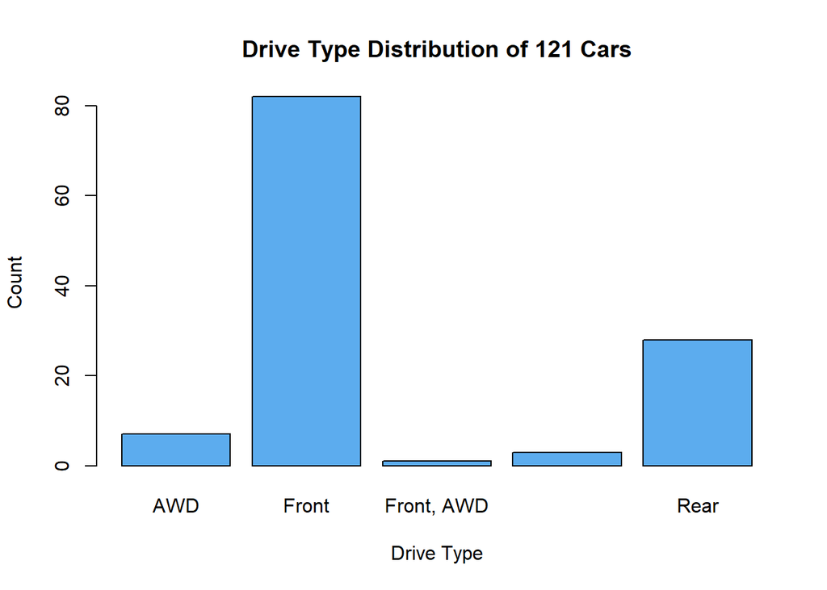

```r
# Bar plot.
barplot(table(car$Drive.Type), # Use table() to tabulate.
        main="Drive Type Distribution of 121 Cars",
        xlab="Drive Type",
        ylab="Count",
        col="steelblue2") # Bar color.
```

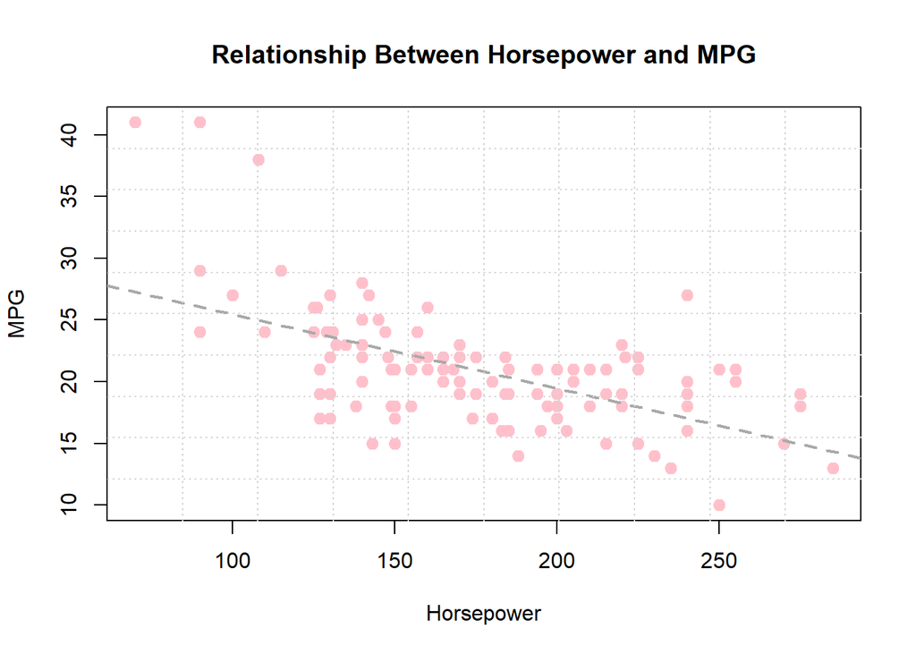

```r
# Scatter plot.
plot(car$Horsepower,
     car$MPG,
     main="Relationship Between Horsepower and MPG",
     xlab="Horsepower",
     ylab="MPG",
     pch=19, # Dot shape.
     col="pink", # Dot color.
     cex=1.2) # Dot size.
abline(lm(car$MPG ~ car$Horsepower), # Use lm() to fit a linear regression.
       lty=2, # Line style: 2 is dotted
       lwd=2, # Line weight i.e. thickness
       col="darkgray")
grid(10, 10) # Add grid lines.
```

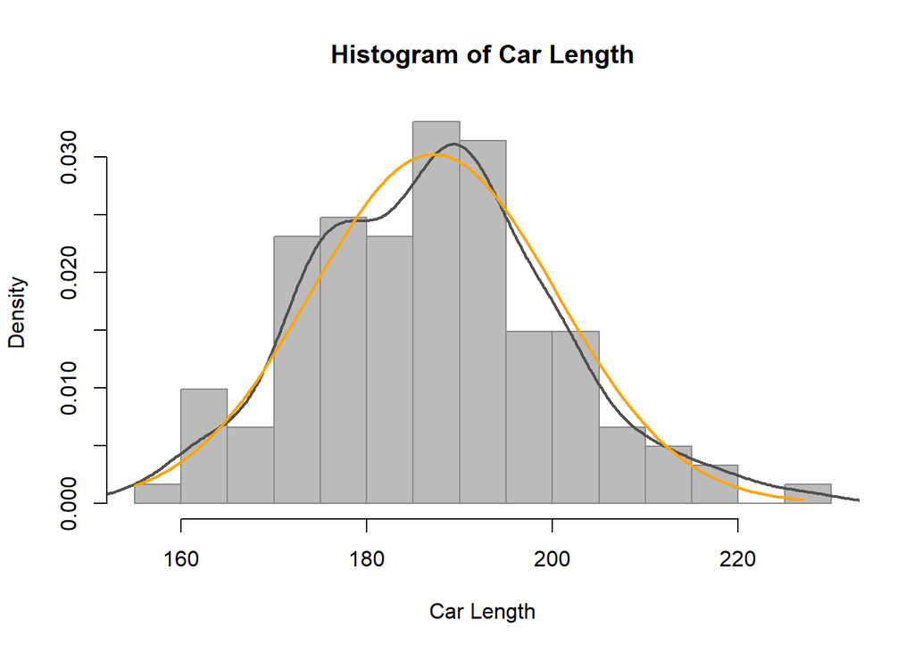

```r
v <- car$Length

# Histogram.
hist(v,
     breaks=20, # Number of bins
     freq=FALSE, # Show density and not count.
     main="Histogram of Car Length",
     xlab="Car Length",
     col="#BBBBBB", # Use HEX color
     border="#888888") # Border color
lines(density(v), # Use density() for kernel density smoothing.
      col=rgb(80,80,80,maxColorValue=255), # Use RGB color
      lwd=2)
# Add a density curve of the normal distribution with matching mean and standard deviation.
lower.v <- min(v)
upper.v <- max(v)
x <- seq(from=lower.v, to=upper.v, length.out=100) # An evenly-spaced sequence.
f.x <- dnorm(x, mean(v), sd(v)) # Use dnorm() for probability density function.
lines(x,   # The x values.
      f.x, # The y values.
      col="orange",
      lwd=2)
```

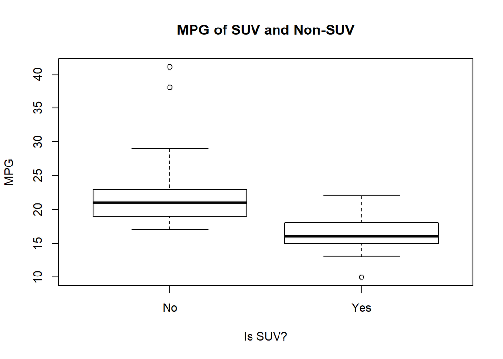

```r
# Boxplot.
boxplot(car$MPG ~ car$SUV, # Group by car$SUV.
        main="MPG of SUV and Non-SUV",
        xlab="Is SUV?",
        ylab="MPG")
```

```r
# Multiple graphs in one figure.
par(mfrow=c(2,2)) # Divide the figure into 2 rows and 2 columns, filled by row.
                  # See also: par(mfcol=...)
plot(...) # Each creates a new plot.
plot(...)
plot(...)
plot(...)
par(mfrow=c(1,1)) # Reset it back to single graph.
```

## 7.2 ggplot

- Nowadays the [ggplot2](http://ggplot2.org/) package is almost the de facto standard for creating nice-looking plots in R.

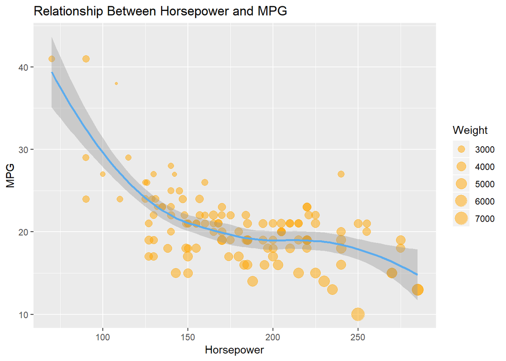

```r
library(ggplot2)

ggplot(car, aes(Horsepower, MPG)) + # Start with a data frame.  Define the axes.
  geom_point(aes(size = Weight), alpha=0.5, colour="orange") + # Add more graphic elements.
  geom_smooth(colour="steelblue2") +
  ggtitle("Relationship Between Horsepower and MPG")
```

## 7.3 Exporting

- There are two ways to export a figure:
  1. Go to Plots → Export → Save as image… or Save as PDF
  2. Draw to a PDF directly using `pdf()` without displaying it on screen.

```r
# Create a PDF file.  Width and height in inches.
pdf("figure.pdf", width=8, height=5)
# Draw directly to the file.
barplot(table(car$Drive.Type),
        main="Drive Type Distribution of 121 Cars",
        xlab="Drive Type",
        ylab="Count",
        col="steelblue2")
dev.off() # Close the file.
```

# 8 Statistics

- Built-in functions: `max()`, `min()`, `range()`, `mean()`, `median()`, `var()`, `sd()`, `quantile()`, `summary()`

```r
mpg <- car$MPG
mean(mpg)
median(mpg)
sd(mpg)
summary(mpg)
```

```
[1] 20.70248
[1] 21
[1] 4.679111
   Min. 1st Qu.  Median    Mean 3rd Qu.    Max.
   10.0    18.0    21.0    20.7    22.0    41.0
```

## 8.1 dplyr

- The [dplyr](https://dplyr.tidyverse.org/) package is very useful for manipulating data frames using SQL-style logic (such as the equivalences of SELECT, WHERE, GROUP BY, and ORDER BY).
- Introductory tutorial: https://cran.rstudio.com/web/packages/dplyr/vignettes/dplyr.html

```r
library(dplyr)

car %>% # Special syntax in "dplyr" to pipe one result to another.
  filter(Horsepower > 100) %>%
  group_by(SUV, Drive.Type) %>%
  summarize(count = n(),
            mean.hp = mean(Horsepower),
            mean.mpg = mean(MPG)) %>%
  arrange(desc(mean.hp))
```

```
# A tibble: 8 x 5
# Groups:   SUV [2]
  SUV   Drive.Type    count mean.hp mean.mpg
  <fct> <fct>         <int>   <dbl>    <dbl>
1 Yes   Front, AWD        1    220      19
2 Yes   Permanent 4WD     3    211      14.3
3 No    Rear             13    207.     21.7
4 Yes   Rear             15    206.     15.5
5 Yes   AWD               4    201      17.5
6 No    Front            69    175      21.6
7 No    AWD               3    175.     20.7
8 Yes   Front             8    149      18.4
```

## 8.2 Randomness

- Built-in functions: `sample()`, `rnorm()`, `runif()`, `rpois()`, and more for other probability distributions. See `?Distributions`.

```r
sample(LETTERS, 10, replace=TRUE)
```

```
 [1] "W" "B" "R" "D" "C" "E" "V" "K" "B" "A"
```

```r
s1 <- rnorm(7, mean=3, sd=2)
s1

s2 <- rnorm(7, mean=3, sd=2) # A different set of values every time.
s2
```

```
[1] 7.7467469 3.7273094 7.7641781 6.4061145 3.1439851 0.6303602 3.1241148
[1] 3.433357 5.350692 6.704618 2.075918 2.236668 4.644586 4.852850
```

```r
set.seed(17) # Set the state of the pseudo-random number generator with an integer.
s3 <- rnorm(7, mean=3, sd=2)
s3

set.seed(17) # Use the same seed to ensure reproducibility.
s4 <- rnorm(7, mean=3, sd=2)
s4
```

```
[1] 0.9699826 2.8407265 2.5340260 1.3654641 4.5441817 2.6687761 4.9457489
[1] 0.9699826 2.8407265 2.5340260 1.3654641 4.5441817 2.6687761 4.9457489
```

# 9 R Markdown

- R Markdown converts your R codes into a report in HTML or PDF format.
- To use R Markdown:
  1. Install the `rmarkdown` package
  2. File → New File → R Markdown…
  3. Edit your .Rmd file.
  4. Click the “Knit HTML” button to generate the HTML file.
- Cheat Sheet: https://www.rstudio.com/resources/cheatsheets/

# 10 Programming Syntax

- R is a programming language with the usual IF ELSE statement, FOR loop, WHILE loop, and function.

```r
# IF ELSE statement.
x <- -3
if (x > 0) {
  answer <- "Positive"
} else if (x == 0)  {
  answer <- "Zero"
} else {
  answer <- "Negative"
}
answer
```

```r
# FOR loop.
phones <- c("Apple", "Samsung", "Nokia", "HTC")

# Method 1: Loop through an index.
total <- 0
for (i in 1:length(phones)) {
    print(i)
    total <- total + nchar(phones[i])
}

# Method 2: Loop through the items themselves.
total <- 0
for (phone in phones) {
    print(phone)
    total <- total + nchar(phone)
}

# But the simplest way is sum(nchar(phones)).  Whenever you loop, think vectorization!
```

```r
# WHILE loop.
x <- 1
while(x < 10) {
  print(paste("Counting:", x)) # See also: paste0()
  x <- x + 1
}
```

```r
# Simple Function.
square <- function(x) {
  return(x^2)
}

square(12)
```

```r
# Function with parameter that has default value.
random.password <- function(n, choice=c(letters, LETTERS)) { # See ?letters.
  if (n <= 0) {
    return(NULL)
  }
  password <- paste0(sample(choice, n, replace=TRUE), collapse="")
  return(password)
}

random.password(10) # Use default value of choice.
random.password(5, 0:9) # Use 0 to 9 instead.
```

```
[1] "ntDVkUXIGd"
[1] "21637"
```

```r
# Functin that returns more than one stuff.
five.number.summary <- function(x) {
  m1 <- min(x)
  q1 <- quantile(x, 0.25, names=FALSE)
  q2 <- median(x)
  q3 <- quantile(x, 0.75, names=FALSE)
  m2 <- max(x)
  return(list(minimum=m1,
              first.quartile=q1,
              median=q2,
              third.quartile=q3,
              maximum=m2)) # Put all the stuff in a list.  Then return one list.
}

x <- c(0.6, 1.7, 0.4, -0.3, -0.3, 0.2, -0.2, -1.5, 1.6, 1.5)
result <- five.number.summary(x)
result
result$first.quartile
```

```
$minimum
[1] -1.5

$first.quartile
[1] -0.275

$median
[1] 0.3

$third.quartile
[1] 1.275

$maximum
[1] 1.7

[1] -0.275
```